# Analysis of Coral Restoration Efforts

A Collaboration with Reef Renewal Bonaire

Tadge McWilliams

May 19th, 2023

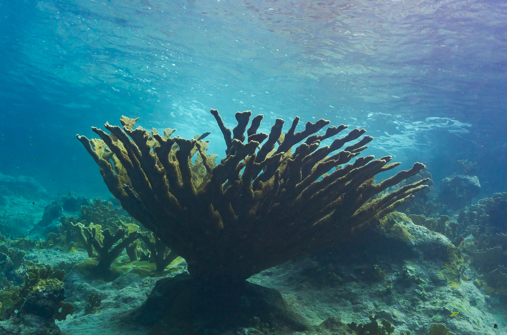

## Summary

The goal of this project is to assist [Reef Renewal Bonaire](https://www.reefrenewalbonaire.org) (RRB) in developing a successful, data driven program to efficiently introduce new, “reef-ready” corals into Bonaire’s reef systems. By analyzing survey data from multiple coral reef outplanting locations, I attempt to provide insights into the viability of two coral species, their genotypes, and the overall changes to the ecological footprints of the restored reef locations. Special interest was given to the performance of coral growth on the geno-level. The successful propagation and growth of multiple genotypes is central to the diversity of the species. Additionally, if certain genotypes prove to be more resistant to temperature fluctuation than others, they may become vitual to the long-term success of the species as we face the realities of climate change. Through mortality and average tissue health calculations, I was able to identify which genotypes are performing better than others and begin to track the changes in tissue health over time. While more analysis is needed, I hope this project will lead to the development of future models from which RRB and others can further their work.

## Ecological Footprint

The following visuals highlight the changes in ecological footprints and total coral coverage from year to year. Data from RRB’s long-term surveys was used for this section. As new outplanting sites are created each year, not all sites have been surveyed equally.

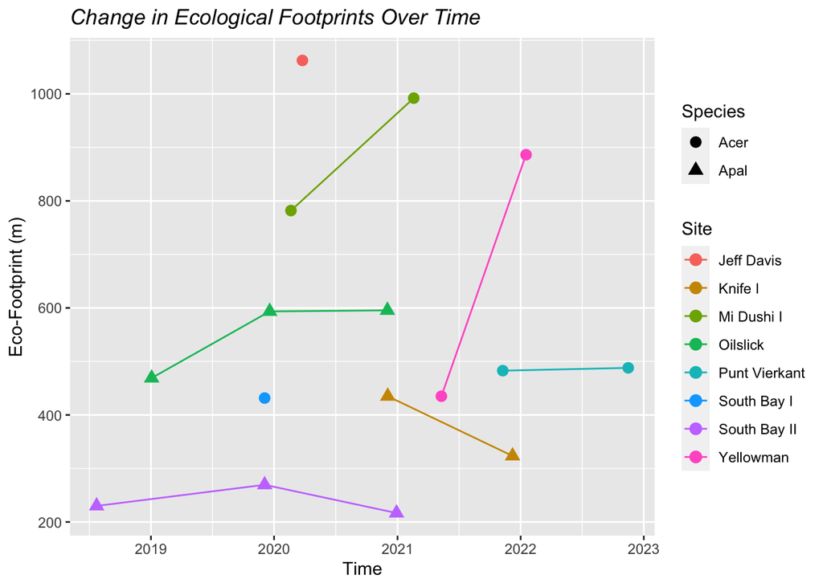

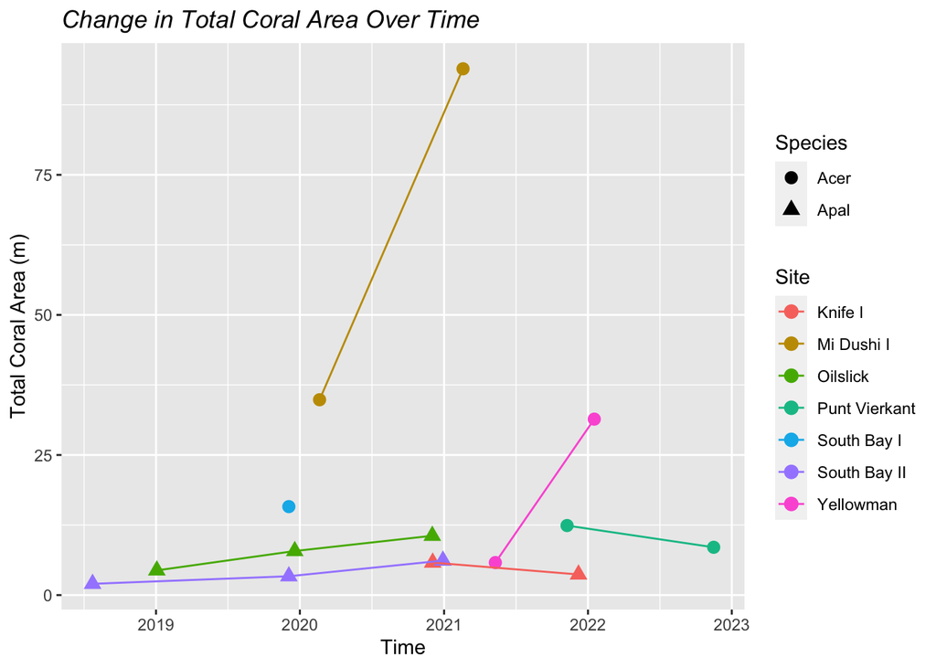

In the visual below, I have highlighted the change in Eco Footprint, Total Coral Area, and Restored Area over time by site. As additional surveys are added, it may be possible to tune a model to predict future trends. Please note that the Total Coral Area and Restored Area often share the same values, or can be quite similar, during the early years of growth.

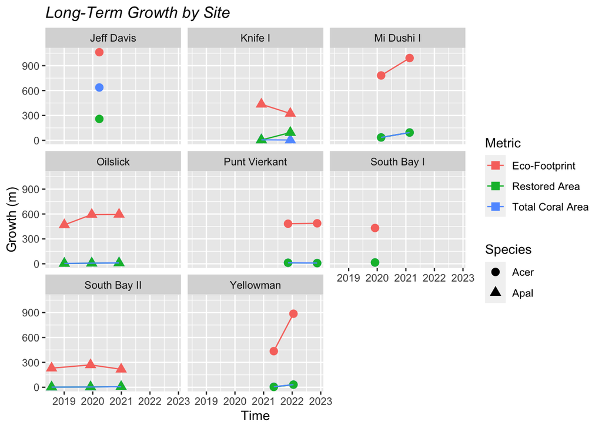

## Species: Apal

### Carl’s Hill 3-Month Survey

Apart from the mortality rate, an important universal metric included in the survey is to record the percentage of healthy coral tissue for each observation. Predation, disease, and other environmental factors are detrimental to coral growth. Below, I have created a weighted average of tissue health by genotype.

| Carl's Hill 3-Month Survey: Ranking Genotypes by Average Tissue Health Species | Carl's Hill 3-Month Survey: Ranking Genotypes by Average Tissue Health Geno | Carl's Hill 3-Month Survey: Ranking Genotypes by Average Tissue Health # Outplanted | Carl's Hill 3-Month Survey: Ranking Genotypes by Average Tissue Health # Survived | Carl's Hill 3-Month Survey: Ranking Genotypes by Average Tissue Health Mortality Rate | Carl's Hill 3-Month Survey: Ranking Genotypes by Average Tissue Health Avg. Health |
| --- | --- | --- | --- | --- | --- |
| Apal | 26 | 5 | 5 | 0% | 97.4% |
| Apal | 5 | 30 | 30 | 0% | 96.8% |
| Apal | 13 | 9 | 9 | 0% | 96.1% |
| Apal | 6 | 15 | 14 | 6.67% | 95.67% |
| Apal | 20 | 20 | 18 | 10% | 95.02% |
| Apal | 10 | 20 | 19 | 5% | 94.95% |
| Apal | 7 | 15 | 16 | -6.67% | 92.68% |
| Apal | 9 | 45 | 43 | 4.44% | 92.18% |
| Apal | 4 | 15 | 14 | 6.67% | 89.72% |
| Apal | 11 | 15 | 13 | 13.33% | 89.64% |
| Apal | 2 | 5 | 5 | 0% | 89.6% |
| Apal | 15 | 5 | 5 | 0% | 87% |
| Apal | 17 | 20 | 19 | 5% | 86.65% |
| Apal | 8 | 40 | 40 | 0% | 85.39% |
| Apal | 1 | 36 | 35 | 2.78% | 84.82% |
| Apal | 16 | 20 | 21 | -5% | 78.44% |
| Apal | 23 | 20 | 20 | 0% | 77.65% |
| Apal | 18 | 15 | 14 | 6.67% | 76.08% |
| Apal | 21 | 30 | 29 | 3.33% | 76% |
| Apal | 19 | 10 | 8 | 20% | 74.55% |
| Apal | 22 | 10 | 10 | 0% | 65% |
| Apal | 14 | 15 | 15 | 0% | 46.25% |

Outliers can easily skew the averages of an aggregate summary. The plot below identifies the range of tissue health by genotype. While the average tissue health of genos #1, #9, and #21 is slightly depressed from a few poorly performing outliers, it appears that genos #14, #16, #18, #19, and #22 are generally less resilient than the others.

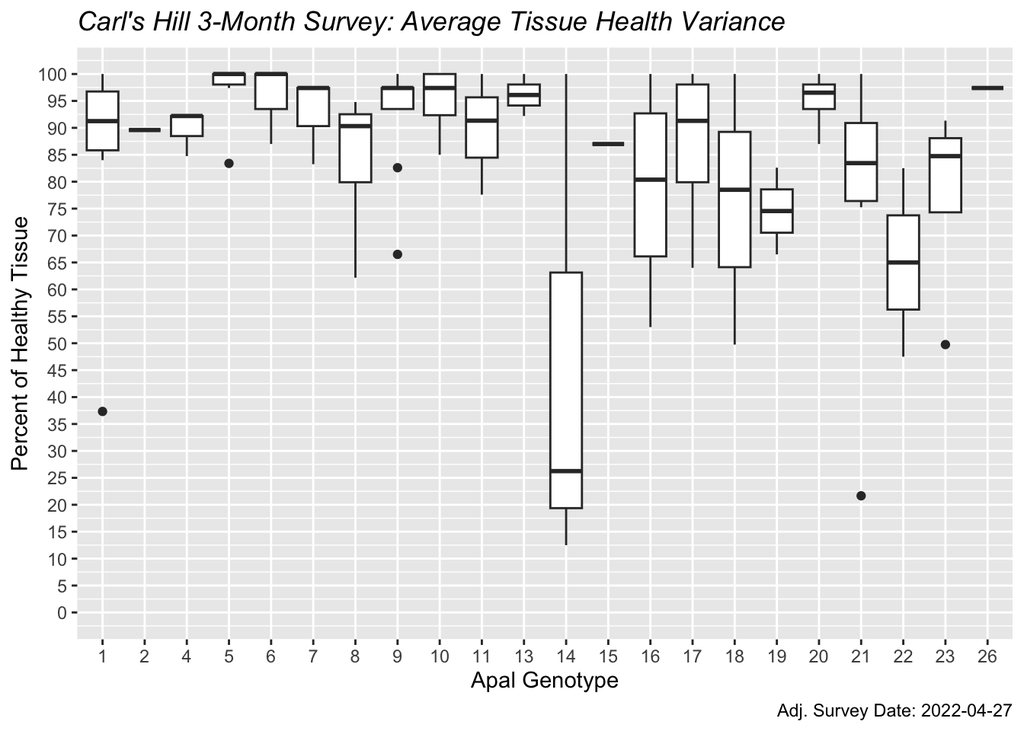

### Carl’s Hill 6-Month Survey

| Carl's Hill 6-Month Survey: Ranking Genotypes by Average Tissue Health Species | Carl's Hill 6-Month Survey: Ranking Genotypes by Average Tissue Health Geno | Carl's Hill 6-Month Survey: Ranking Genotypes by Average Tissue Health # Outplanted | Carl's Hill 6-Month Survey: Ranking Genotypes by Average Tissue Health # Survived | Carl's Hill 6-Month Survey: Ranking Genotypes by Average Tissue Health Mortality Rate | Carl's Hill 6-Month Survey: Ranking Genotypes by Average Tissue Health Avg. Health |
| --- | --- | --- | --- | --- | --- |
| Apal | 6 | 10 | 7 | 30% | 100% |
| Apal | 7 | 20 | 19 | 5% | 96.52% |
| Apal | 9 | 10 | 9 | 10% | 96.1% |
| Apal | 5 | 10 | 10 | 0% | 93.9% |
| Apal | 26 | 10 | 9 | 10% | 93.18% |
| Apal | 22 | 5 | 5 | 0% | 93% |
| Apal | 4 | 15 | 15 | 0% | 89.6% |
| Apal | 13 | 10 | 10 | 0% | 89.35% |
| Apal | 10 | 15 | 15 | 0% | 88.97% |
| Apal | 23 | 10 | 10 | 0% | 86.48% |
| Apal | 11 | 15 | 9 | 40% | 82.29% |
| Apal | 18 | 10 | 8 | 20% | 72.5% |
| Apal | 21 | 15 | 15 | 0% | 71.82% |
| Apal | 1 | 15 | 15 | 0% | 70.13% |
| Apal | 19 | 10 | 8 | 20% | 65% |
| Apal | 20 | 10 | 9 | 10% | 55.96% |
| Apal | 17 | 10 | 10 | 0% | 54.78% |
| Apal | 16 | 10 | 9 | 10% | 51.38% |
| Apal | 15 | 10 | 5 | 50% | 49.75% |
| Apal | 14 | 10 | 10 | 0% | 41.92% |
| Apal | 8 | 10 | 8 | 20% | 40.44% |
| Apal | 2 | 5 | 5 | 0% | 12.5% |

The changes in variance between the three- and six-month surveys often correspond with the addition of new stressors to some of the observations.

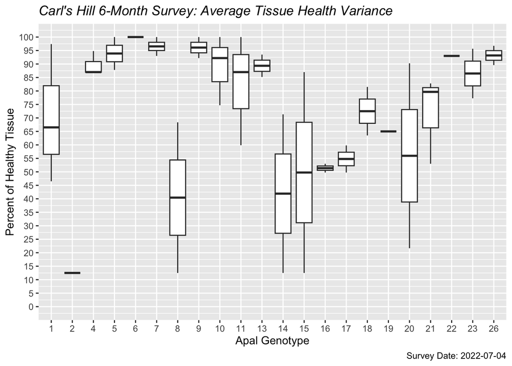

To better visualize the change in tissue health, I have summarized the average tissue health for each genotype during the three- and six-month surveys. Comparing changes and combining the data from other Apal sites may help create a more diverse sample and reduce site bias.

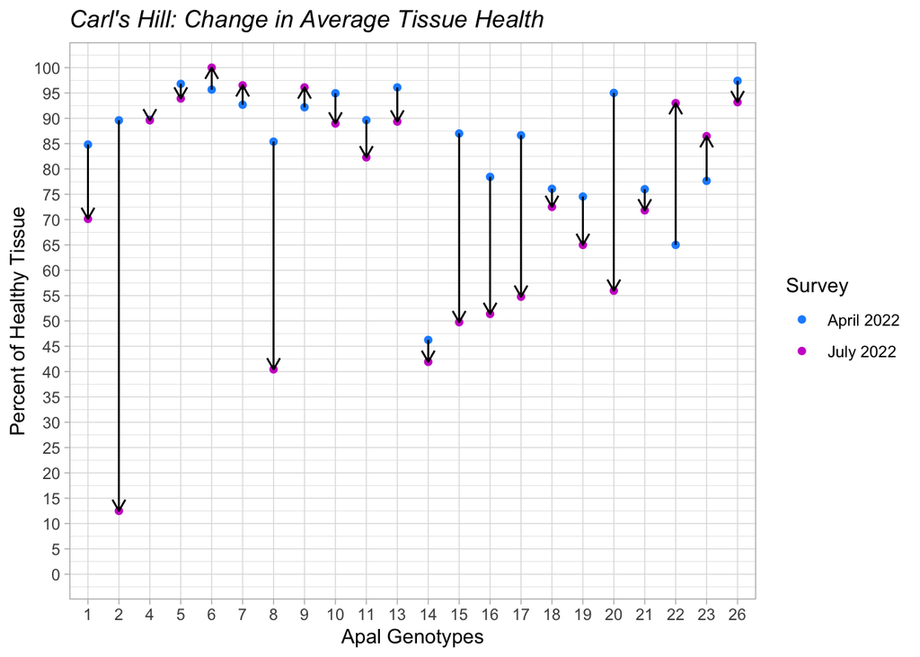

## Species: Acer

The following data was taken from surveys conducted across the Yellowman sites. Within the Yellowman site, there are A, B, and C sub-sites.

The Acer species appears to be more successful than the Apal. Over 700 more corals were outplanted at the Yellowman A location than at Carl’s Hill with 11 fewer fatalities. Additional factors are likely to contribute to these statistics; however, it is worth noting that the two locations are quite geographically close to one another. The Yellowman sites would be subject to much of the same conditions as Carl’s Hill.

### Yellowman A 3-Month Survey

While mortality rates are consistently low for the species, there is a broad range in average tissue health. Genos #14, #21, and #22 are notably less successful than #17-#20.

| Yellowman A 3-Month Survey: Ranking Genotypes by Average Tissue Health Species | Yellowman A 3-Month Survey: Ranking Genotypes by Average Tissue Health Geno | Yellowman A 3-Month Survey: Ranking Genotypes by Average Tissue Health # Outplanted | Yellowman A 3-Month Survey: Ranking Genotypes by Average Tissue Health # Survived | Yellowman A 3-Month Survey: Ranking Genotypes by Average Tissue Health Mortality Rate | Yellowman A 3-Month Survey: Ranking Genotypes by Average Tissue Health Avg. Health |
| --- | --- | --- | --- | --- | --- |
| Acer | 19 | 161 | 160 | 0.62% | 98.08% |
| Acer | 18 | 160 | 159 | 0.62% | 96.44% |
| Acer | 20 | 161 | 160 | 0.62% | 94.7% |
| Acer | 17 | 150 | 150 | 0% | 94.47% |
| Acer | 15 | 152 | 152 | 0% | 93.24% |
| Acer | 13 | 80 | 80 | 0% | 91.92% |
| Acer | 16 | 179 | 179 | 0% | 89.88% |
| Acer | 1 | 50 | 49 | 2% | 86.3% |
| Acer | 21 | 153 | 153 | 0% | 82.42% |
| Acer | 14 | 60 | 60 | 0% | 74.35% |
| Acer | 22 | 38 | 38 | 0% | 54.36% |

The plot below identifies the range of tissue health by genotype. Few outliers help to confirm the average health statistics are representative of each geno’s viability.

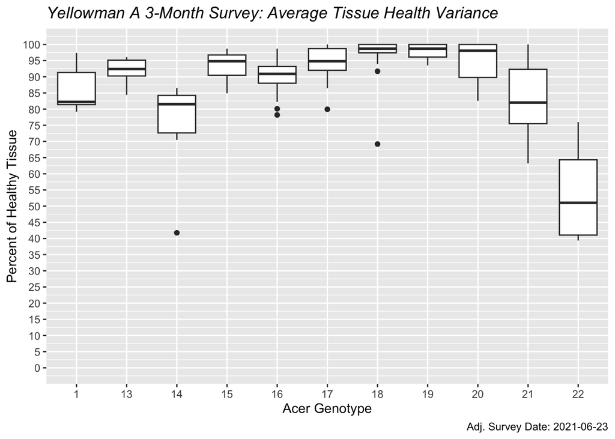

### Yellowman A 6-Month Survey

After six months, genos #17, #21, and #22 still have a 0% mortality rate.

| Yellowman A 6-Month Survey: Ranking Genotypes by Average Tissue Health Species | Yellowman A 6-Month Survey: Ranking Genotypes by Average Tissue Health Geno | Yellowman A 6-Month Survey: Ranking Genotypes by Average Tissue Health # Outplanted | Yellowman A 6-Month Survey: Ranking Genotypes by Average Tissue Health # Survived | Yellowman A 6-Month Survey: Ranking Genotypes by Average Tissue Health Mortality Rate | Yellowman A 6-Month Survey: Ranking Genotypes by Average Tissue Health Avg. Health |
| --- | --- | --- | --- | --- | --- |
| Acer | 19 | 161 | 161 | 0% | 91.27% |
| Acer | 20 | 150 | 150 | 0% | 80.59% |
| Acer | 15 | 110 | 108 | 1.82% | 79.94% |
| Acer | 17 | 140 | 140 | 0% | 79.92% |
| Acer | 1 | 50 | 50 | 0% | 79.34% |
| Acer | 18 | 121 | 120 | 0.83% | 79.29% |
| Acer | 13 | 80 | 79 | 1.25% | 76.53% |
| Acer | 16 | 159 | 158 | 0.63% | 73.77% |
| Acer | 21 | 120 | 120 | 0% | 55.67% |
| Acer | 14 | 60 | 59 | 1.67% | 51.21% |
| Acer | 22 | 38 | 38 | 0% | 27.34% |

The variance of tissue health below remains relatively stable. Most corals have decreased in average health, but the interquartile range of observations is fairly close.

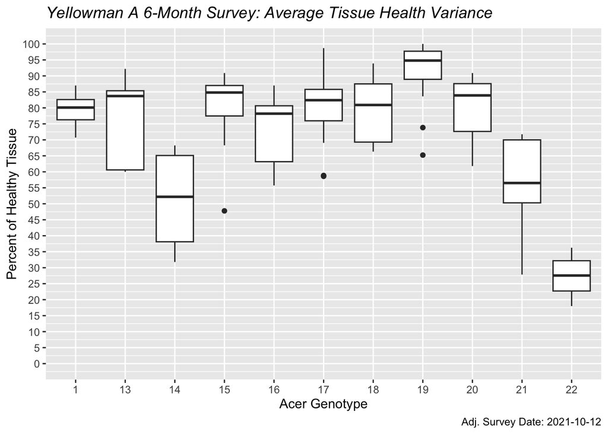

The visual below indicates a more pronounced decline in tissue health than from the Carl’s Hill surveys. The percent decline of each geno has a *71.7% correlation* with the initial average health rating of that geno. This correlation could be investigated further to see if a more diverse sample of the population yields a more robust model.

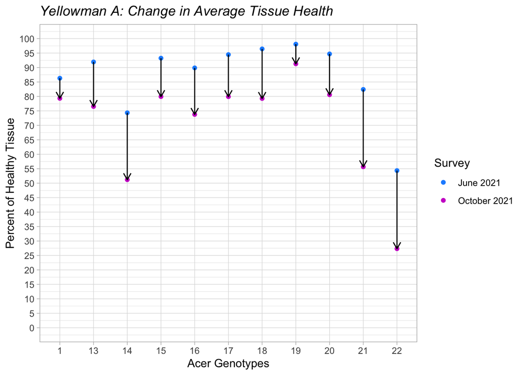

### Yellowman B 3-Month Survey

At Yellowman B, RRB outplanted different genotypes from those at Yellowman A. Only geno #1 is shared between Yellowman A and Yellowman B.

| Yellowman B 3-Month Survey: Ranking Genotypes by Average Tissue Health Species | Yellowman B 3-Month Survey: Ranking Genotypes by Average Tissue Health Geno | Yellowman B 3-Month Survey: Ranking Genotypes by Average Tissue Health # Outplanted | Yellowman B 3-Month Survey: Ranking Genotypes by Average Tissue Health # Survived | Yellowman B 3-Month Survey: Ranking Genotypes by Average Tissue Health Mortality Rate | Yellowman B 3-Month Survey: Ranking Genotypes by Average Tissue Health Avg. Health |
| --- | --- | --- | --- | --- | --- |
| Acer | 25 | 50 | 49 | 2% | 99.45% |
| Acer | 23 | 50 | 50 | 0% | 96.02% |
| Acer | 8 | 52 | 52 | 0% | 95.23% |
| Acer | 4 | 60 | 60 | 0% | 93.41% |
| Acer | 26 | 50 | 50 | 0% | 93.24% |
| Acer | 11 | 52 | 51 | 1.92% | 92.89% |
| Acer | 12 | 60 | 60 | 0% | 91.77% |
| Acer | 7 | 60 | 60 | 0% | 90.54% |
| Acer | 10 | 60 | 60 | 0% | 90.47% |
| Acer | 24 | 50 | 50 | 0% | 89.08% |
| Acer | 1 | 60 | 60 | 0% | 85.75% |
| Acer | 6 | 60 | 60 | 0% | 84.82% |
| Acer | 5 | 50 | 50 | 0% | 83.43% |
| Acer | 3 | 60 | 60 | 0% | 73.22% |
| Acer | 9 | 50 | 50 | 0% | 50.12% |

With the exception of geno #9, most genotypes have relatively high average tissue health.

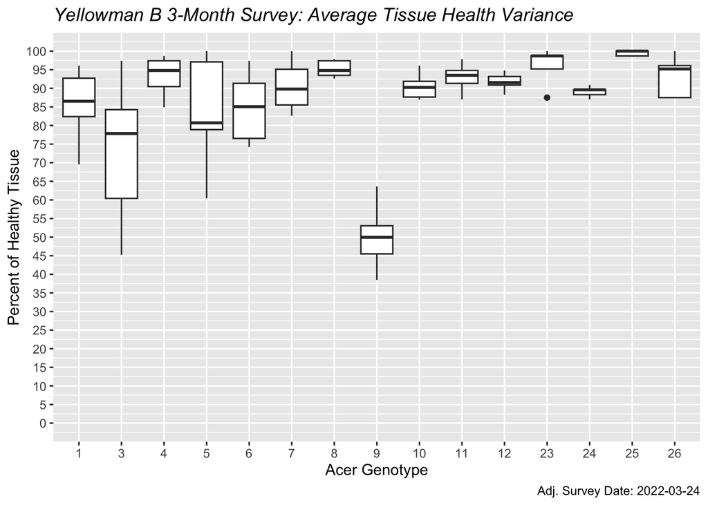

### Yellowman B 6-Month Survey

The six-month survey of Yellowman B shows quite a low mortality rate.

| Yellowman B 6-Month Survey: Ranking Genotypes by Average Tissue Health Species | Yellowman B 6-Month Survey: Ranking Genotypes by Average Tissue Health Geno | Yellowman B 6-Month Survey: Ranking Genotypes by Average Tissue Health # Outplanted | Yellowman B 6-Month Survey: Ranking Genotypes by Average Tissue Health # Survived | Yellowman B 6-Month Survey: Ranking Genotypes by Average Tissue Health Mortality Rate | Yellowman B 6-Month Survey: Ranking Genotypes by Average Tissue Health Avg. Health |
| --- | --- | --- | --- | --- | --- |
| Acer | 7 | 50 | 49 | 2% | 90.86% |
| Acer | 4 | 60 | 60 | 0% | 89.09% |
| Acer | 12 | 70 | 70 | 0% | 87.61% |
| Acer | 10 | 50 | 50 | 0% | 86.47% |
| Acer | 11 | 50 | 50 | 0% | 85.38% |
| Acer | 6 | 50 | 50 | 0% | 83.65% |
| Acer | 26 | 50 | 50 | 0% | 83.55% |
| Acer | 8 | 50 | 49 | 2% | 82.83% |
| Acer | 24 | 60 | 60 | 0% | 82.77% |
| Acer | 25 | 50 | 50 | 0% | 81.03% |
| Acer | 23 | 50 | 50 | 0% | 78.9% |
| Acer | 5 | 50 | 50 | 0% | 73.84% |
| Acer | 3 | 60 | 60 | 0% | 65.94% |
| Acer | 1 | 60 | 59 | 1.67% | 65.08% |
| Acer | 9 | 50 | 50 | 0% | 33.89% |

There are many tissue health outliers in the six-month survey. Disease, ciliate, and fireworm stressors were common. However, geno #9 had the lowest average tissue health of any Yellowman B geno, but only one fireworm stressor was recorded out of the 50 corals observed. This indicates its poorer performance is not due to the observed stressors.

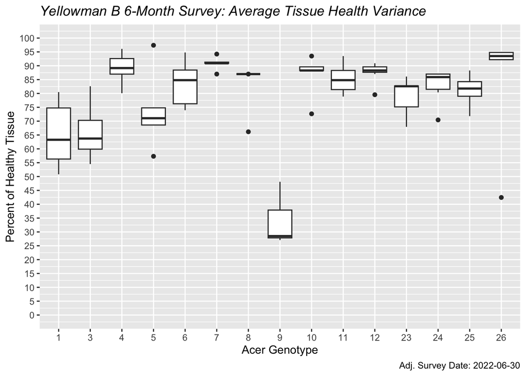

The average change in tissue health between surveys is lower at Yellowman B than at other sites. This data furthers the possibility that the genotypes at Yellowman B are more resiliant than those at Yellowman A.

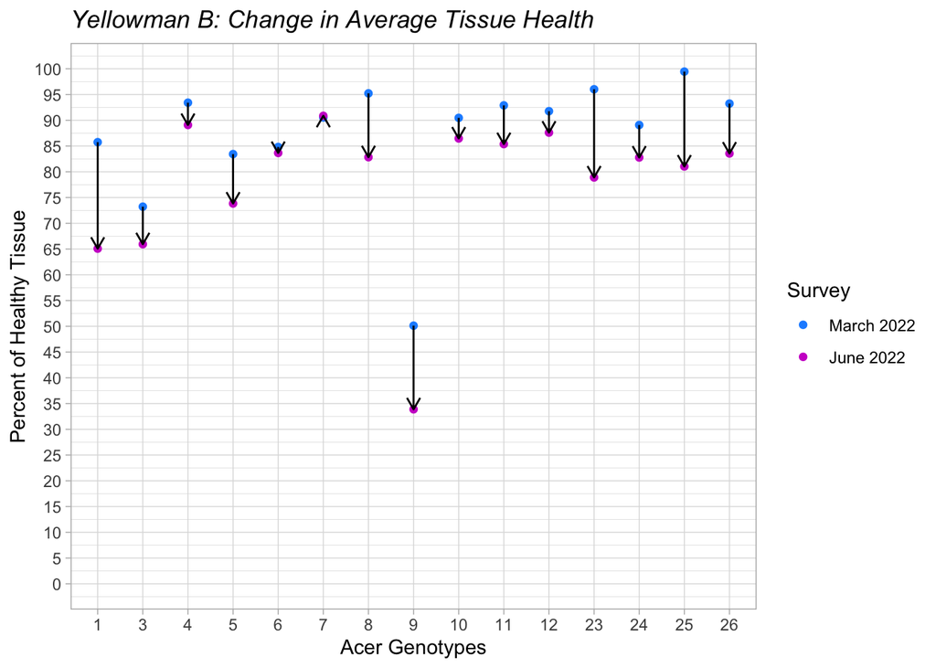

### Yellowman C 3-Month Survey

The Yellowman C site shares many of the same genos as at Yellowman A. The mortality rate, however, is much greater at Yellowman C.

| Yellowman C 3-Month Survey: Ranking Genotypes by Average Tissue Health Species | Yellowman C 3-Month Survey: Ranking Genotypes by Average Tissue Health Geno | Yellowman C 3-Month Survey: Ranking Genotypes by Average Tissue Health # Outplanted | Yellowman C 3-Month Survey: Ranking Genotypes by Average Tissue Health # Survived | Yellowman C 3-Month Survey: Ranking Genotypes by Average Tissue Health Mortality Rate | Yellowman C 3-Month Survey: Ranking Genotypes by Average Tissue Health Avg. Health |
| --- | --- | --- | --- | --- | --- |
| Acer | 15 | 61 | 54 | 11.48% | 83.76% |
| Acer | 19 | 10 | 10 | 0% | 82.6% |
| Acer | 13 | 40 | 34 | 15% | 76.2% |
| Acer | 16 | 50 | 41 | 18% | 71.51% |
| Acer | 18 | 30 | 30 | 0% | 67.87% |
| Acer | 21 | 31 | 30 | 3.23% | 60.93% |
| Acer | 14 | 30 | 30 | 0% | 60.76% |
| Acer | 3 | 20 | 13 | 35% | 60.69% |
| Acer | 20 | 59 | 55 | 6.78% | 51.16% |

Stressors were present in all but three of the observations. It is likely stressors are an important factor in the lower average tissue health at the site. A six-month survey is not yet available for Yellowman C. In the future, it will be interesting to compare the three- to six-month changes at Yellowman C with those at Yellowman A.

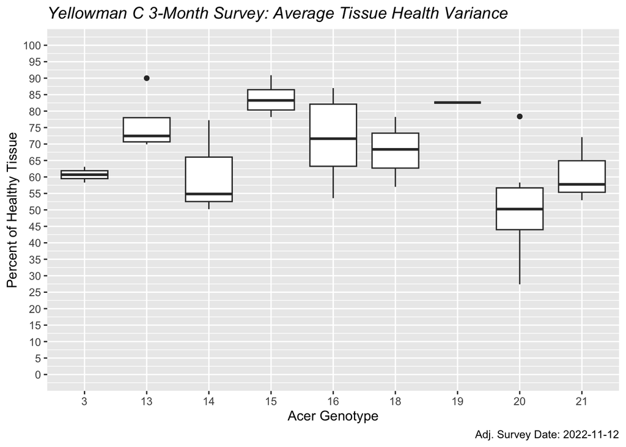

### Comparing Yellowman Sites

In the visual below, I have extracted the genotypes present at both Yellowman A and Yellowman C, as of their three-month surveys. The data suggests that the corals at Yellowman A are out performing those at Yellowman C. One noteworthy difference is that the Yellowman A survey was conducted in June 2021 while the Yellowman C survey was conducted in November 2022. Seasonal water temperatures would have differed during the preceding three months, creating a potentially unequal environment for comparison. It is unknown if differences in propagation or outplanting techniques existed between the two sites.

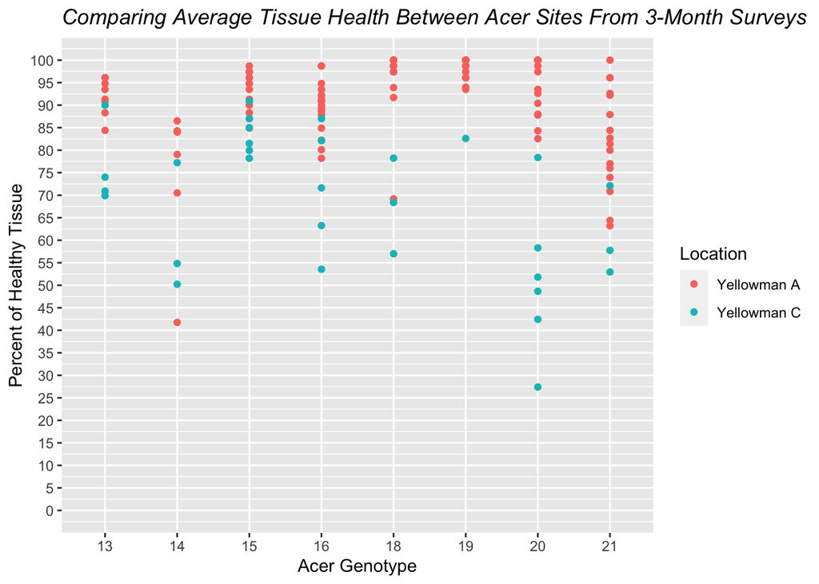

## Actionable Opportunities

There are a variety of stressors that are detrimental to the success of coral growth. The majority of these are out of the control of restoration efforts. Bottom Contact, however, a stressor caused from coral agitation against the seafloor, typically occurs when corals break free from their placements. While this is unavoidable during storms and wind-reversals, there is an opportunity to reduce the amount of overall bottom contact events through improved adhesives. New adhesive technologies are expected to be introduced in 2023. Comparing the percentage of Bottom Contact observations between existing sites and future sites may prove to be a useful indicator of the technology’s efficacy and value.

| Carl's Hill 3-Month Survey # Surveyed | Carl's Hill 3-Month Survey Total Stressors | Carl's Hill 3-Month Survey Bottom Contact | Carl's Hill 3-Month Survey Percent of Surveyed |
| --- | --- | --- | --- |
| 85 | 127 | 45 | 52.94% |

| Carl's Hill 6-Month Survey # Surveyed | Carl's Hill 6-Month Survey Total Stressors | Carl's Hill 6-Month Survey Bottom Contact | Carl's Hill 6-Month Survey Percent of Surveyed |
| --- | --- | --- | --- |
| 50 | 35 | 1 | 2% |

| Yellowman B 3-Month Survey # Surveyed | Yellowman B 3-Month Survey Total Stressors | Yellowman B 3-Month Survey Bottom Contact | Yellowman B 3-Month Survey Percent of Surveyed |
| --- | --- | --- | --- |
| 82 | 129 | 53 | 64.63% |

| Yellowman B 6-Month Survey # Surveyed | Yellowman B 6-Month Survey Total Stressors | Yellowman B 6-Month Survey Bottom Contact | Yellowman B 6-Month Survey Percent of Surveyed |
| --- | --- | --- | --- |
| 81 | 91 | 5 | 6.17% |

| Yellowman C 3-Month Survey # Surveyed | Yellowman C 3-Month Survey Total Stressors | Yellowman C 3-Month Survey Bottom Contact | Yellowman C 3-Month Survey Percent of Surveyed |
| --- | --- | --- | --- |
| 33 | 53 | 23 | 69.7% |

[^1]: Goergen, E.A., Schopmeyer, S., Moulding, A.L., Moura, A., Kramer, P., and Viehman, T.S. 2020. Coral Reef Restoration Monitoring Guide: Methods to Evaluate Restoration Success From Local to Ecosystem Scales. NOAA Technical Memorandum NOS NCCOS 279. Silver Spring, MD. 158 pp. https://doi.org/10.25923/xndz-h538